# Exercises lecture 3 – data wrangling

Paolo Crosetto

9/11/2019

# `filter()` & `select()`

## Exercice 1

> sauvegardez dans un nouvel objet tous les vols partis entre midi et deux heures, en gardant juste l’info sur l’aéroport de départ et d’arrivée

```r
tem <-filter(df, dep_time>=1200 & dep_time<=1400)
x1 <-select(tem,origin, dest)
```

```r
df %>%
  filter(dep_time>=1200 & dep_time<=1400)%>%
  select(origin,dest) -> x1bis
```

## Exercice 2

> isolez dans un nouvel objet tous les vols partis entre minuit et une heure du matin de JFK et de LGA. Quelle est, pour chacun de deux aéroport, la destionation la plus fréquente?

```r
df %>%
  filter(dep_time>=0 & dep_time<0100) %>%
  filter(origin %in% c("JFK","LGA")) -> ex2
```

## Exercice 3

> y a-t-il une rélation entre heure de départ et retard au départ? répondez avec un plot (geom_point + geom_smooth)

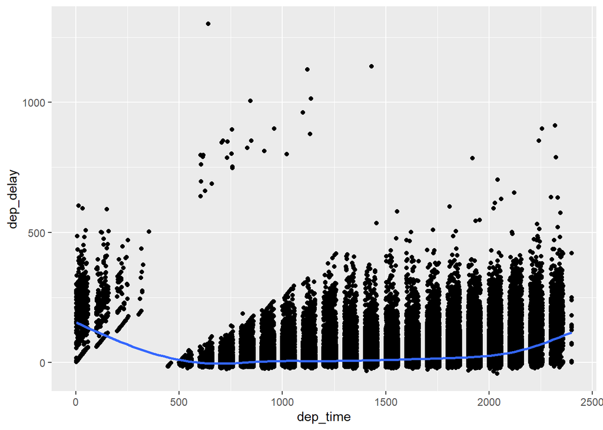

```r
df %>%
  ggplot(aes(dep_time, dep_delay)) +
  geom_point() +
  geom_smooth()
```

# `mutate()`

## Exercice 4

> créez une variable qui montre la vitesse de chaque avion

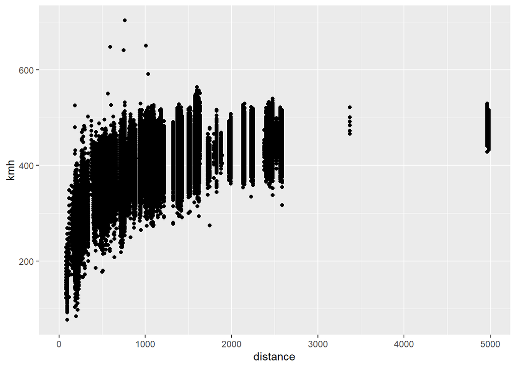

```r
df %>%
  mutate(vitesse = distance / air_time,
         kmh= vitesse*60/ 1,61) %>%
  select(kmh, vitesse, distance, air_time, everything()) %>%
  ggplot(aes(x = distance, y = kmh))+
  geom_point()
```

## Exercice 5

> créez une variable qui calcule l’impact (en %) du retard à l’arrivée sur le temps de vol

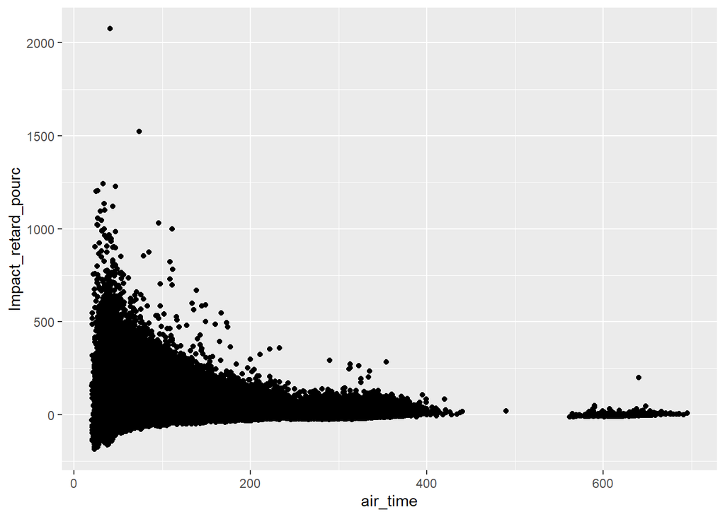

```r
df %>%
  mutate(Impact_retard_pourc = (100*arr_delay) / air_time) %>%
  select(Impact_retard_pourc,everything())%>%
  ggplot(aes(x = air_time, y= Impact_retard_pourc))+
  geom_point()
```

# `summarise()` and `group_by()`

## Exercice 6

> calculez la moyenne, l’écart type, le min et le max du rétard à l’arrivée

```r
df %>%
  summarise(moyenne = mean(arr_delay, na.rm = T),
            ecart_type = sd(arr_delay, na.rm =T),
            min = min(arr_delay, na.rm = T),
            max = max(arr_delay, na.rm = T)) -> ex6
```

## Exercice 7

> même chose que l’exercice 6, mais par aéroport de départ, avec comme seule compagnie AA

```r
df %>%
  filter(carrier == "AA") %>%
  group_by(origin) %>%
  summarise(moyenne = mean(arr_delay, na.rm = T),
            ecart_type = sd(arr_delay, na.rm =T),
            min = min(arr_delay, na.rm = T),
            max = max(arr_delay, na.rm = T))
```

```
## # A tibble: 3 x 5
##   origin moyenne ecart_type   min   max
##   <chr>    <dbl>      <dbl> <dbl> <dbl>
## 1 EWR      0.978       48.3   -67   878
## 2 JFK      2.08        43.9   -75  1007
## 3 LGA     -1.33        39.7   -68   802
```

## Exercice 8

> plottez la moyenne du retard d’arrivée par compagnie aérienne

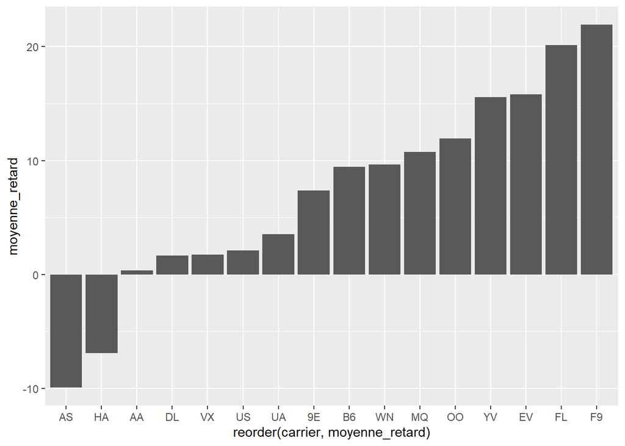

```r
df %>%
  group_by(carrier) %>%
  summarise(moyenne_retard = mean(arr_delay, na.rm = T)) %>%
  ggplot( aes(x = reorder(carrier, moyenne_retard), y = moyenne_retard))+
  geom_col()
```

## Exercice 9 – filter + select + mutate + summarise + group_by

> quelle est la vitesse moyenne des vols qui partent entre 11h et 13h, par mois?

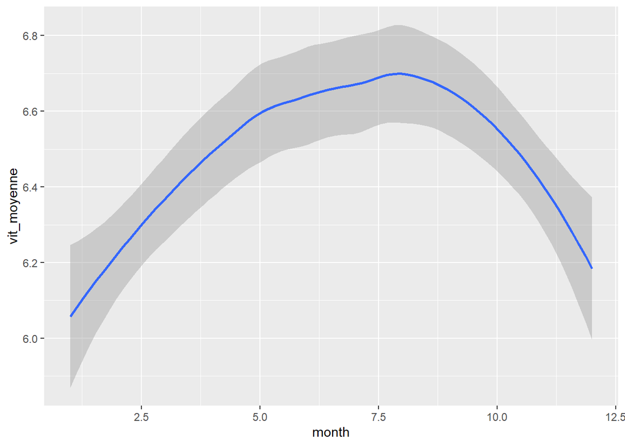

```r
df %>%
  filter(dep_time>=1100 & dep_time<1300) %>%
  group_by(month) %>%
  mutate(vitesse = distance / air_time) %>%
  summarise(vit_moyenne = mean(vitesse, na.rm = T)) %>%
  ggplot(aes(x=month, y= vit_moyenne))+
  geom_smooth()
```

# meet the pipe: `%>%`

## meta-exercice 1

> **re-faites** *tous* les exercices ci-dessus en utilisant l’opérateur ‘et après’ / pipe `%>%`

## Exercice 10

> trouvez le maximum retard au depart par aéroport pour JFK et LGA pour chaque jour de l’an. Plottez les résultats. Est-ce que les retards sont corrélés? Montrez la corrélation avec un plot.

## Exercice 11

> de quel aéroport partent les vols à plus longue distance?

# `join_...()` family of functions

> first run thi setup R code chunk. It will load in your workspace 3 data frames:
- **airports**: avec données sur les aéroports américains
- **flights**: qu’on connait déjà
- **planes**: avec les données pour chaque avion

```r
planes <- planes
flights <- flights
airports <- airports
```

## Exercice 12

> est-ce que les routes plus longues sont desservies apr les avions les plus modernes?

*notes*: utilisez `left_join()` et mergez les dataframes `flights` et `planes`

## Exercice 13

> combien de vols qui partent des trois aéroport de NY atterrsient dans des destinations lus de 1000m s.n.m.?

```r
table1
```

```
## # A tibble: 6 x 4
##   country      year  cases population
##   <chr>       <int>  <int>      <int>
## 1 Afghanistan  1999    745   19987071
## 2 Afghanistan  2000   2666   20595360
## 3 Brazil       1999  37737  172006362
## 4 Brazil       2000  80488  174504898
## 5 China        1999 212258 1272915272
## 6 China        2000 213766 1280428583
```

# creating tidy data: reshape with `gather()` and `spread()`

## Exercice 14

> tidy world_bank_pop dataset so that ‘year’ is a variable and for each country and each year you have urban population and urban population growh only. Plot as a geom_line the total population for each country over the years.